# index

## De Word Embeddings a Similitud Semántica

## Fundamentos Matemáticos de la Representación del Lenguaje

**Presentado por:** Natali Angarita Escolar **Maestría en Estadística Aplicada** Universidad del Norte

### 1. De Representaciones por Frecuencia a Representaciones por Embeddings

Las representaciones textuales tradicionales como **Bag-of-Words (BoW)** y **TF-IDF** codifican documentos como vectores dispersos cuyos elementos reflejan conteos de palabras o frecuencias ponderadas. Como ua hemos expuesto en documentos anteriores, estos enfoques son puramente *léxicos*: Se centran en la forma del texto más no en el fondo. Teniendo así que dos documentos que usan palabras distintas para expresar la misma idea resultan muy diferentes, mientras que dos documentos que comparten muchas palabras funcionales pueden parecer similares aunque su difieran en su significado.

Para abordar esta limitación, se introduce la técnica de **word embeddings**, que consiste en representar cada palabra como un vector denso dentro de un espacio continuo aprendido a partir de grandes volúmenes de texto. Su fundamento se basa en la hipótesis distribucional, según la cual las palabras que comparten contextos similares tienden a tener significados similares. En consecuencia, estas palabras adquieren representaciones vectoriales cercanas entre sí. Así, la similitud en el significado se refleja como cercanía en el espacio geométrico.

### 2. Descripción del Modelo de Embedding

| Atributo | Valor |
| --- | --- |
| Modelo | GloVe (Global Vectors) |
| Identificador | `glove-wiki-gigaword-100` |
| Corpus | Wikipedia + Gigaword (~6B tokens) |
| Vocabulario | 400,000 tokens |
| Dimensiones | 100 |
| Cargado con | `gensim.downloader` |

**GloVe** (Global Vectors for Word Representation) es un modelo de procesamiento de lenguaje natural que se utiliza para aprender representaciones vectoriales de palabras, conocidas como embeddings. Su objetivo es capturar el significado de las palabras a partir de cómo coaparecen con otras en un gran corpus de texto. A diferencia de otros métodos que se basan en contextos locales, GloVe aprovecha información global del lenguaje mediante una matriz de co-ocurrencias. Dicha matriz no es más que una tabla que muestra cuántas veces aparecen juntas dos palabras en un texto dentro de un cierto contexto (por ejemplo, en la misma oración o cerca una de otra).El resultado es que cada palabra se representa como un vector numérico de 100 dimensiones que refleja sus relaciones semánticas y sintácticas.

```python
import numpy as np
import gensim
import gensim.downloader as api

import pandas as pd
import matplotlib.pyplot as plt
import matplotlib.patches as mpatches


# ── Reproducibilidad ──────────────────────────────────────────────
np.random.seed(42)

# ── Cargar modelo GloVe preentrenado ──────────────────────────────
# Modelo  : GloVe (Global Vectors for Word Representation)
# Corpus  : Wikipedia 2014 + Gigaword 5 (≈ 6 mil millones de tokens)
# Dim     : 100
modelo = api.load("glove-wiki-gigaword-100")

print(f"Modelo       : GloVe (glove-wiki-gigaword-100)")
print(f"Corpus       : Wikipedia + Gigaword (~6B tokens)")
print(f"Vocabulario  : {len(modelo.key_to_index):,} tokens")
print(f"Dimensiones  : {modelo.vector_size}")

# ── Pares de palabras ────────────────────────────────────────────
pares = [
    ("king", "queen"),     # cercanas (semánticamente relacionadas)
    ("car", "automobile"), # casi sinónimos
    ("dog", "cat"),        # misma categoría

    ("king", "banana"),    # no relacionadas
    ("car", "tree"),
    ("computer", "banana")
]

# ── Calcular similitud ───────────────────────────────────────────
resultados = []

for w1, w2 in pares:
    similitud = modelo.similarity(w1, w2)
    resultados.append((w1, w2, similitud))

df_sim = pd.DataFrame(resultados, columns=["Palabra 1", "Palabra 2", "Similitud"])

print("\nSimilitud semántica con GloVe:\n")
print(df_sim)
```

```
Modelo       : GloVe (glove-wiki-gigaword-100)
Corpus       : Wikipedia + Gigaword (~6B tokens)
Vocabulario  : 400,000 tokens
Dimensiones  : 100

Similitud semántica con GloVe:

  Palabra 1   Palabra 2  Similitud
0      king       queen   0.750769
1       car  automobile   0.683194
2       dog         cat   0.879807
3      king      banana   0.160888
4       car        tree   0.354176
5  computer      banana   0.121274
```

### 3. Exploración del Vocabulario

Seleccionamos un conjunto de 20 palabras correctamente escritas, 4 palabras que identifican las limitaciones del corpus.

A continuación verificamos su presencia en el vocabulario del modelo.

```python
candidatos = [
    # Académico / profesional
    "class", "professor", "student", "lecture", "research",
    # Política
    "democracy", "election", "parliament", "senate", "congress",
    "diplomacy", "sovereignty", "ideology", "referendum",
    # Geografía / cotidiano
    "city", "river", "mountain", "economy", "health", "cloud",
    # Ejemplos que no deben estar
    "Natalí", "enginier", "TikTok", "OOV"
]

en_vocab  = [w for w in candidatos if w     in modelo.key_to_index]
fuera_vocab = [w for w in candidatos if w not in modelo.key_to_index]

print("Palabras en vocabulario:")
for w in en_vocab:
    print(f"  ✔  {w}")

print(f"\nPalabras fuera de vocabulario: {fuera_vocab if fuera_vocab else 'Ninguna'}")
print(f"\nCobertura: {len(en_vocab)}/{len(candidatos)} palabras encontradas")
```

```
Palabras en vocabulario:
  ✔  class
  ✔  professor
  ✔  student
  ✔  lecture
  ✔  research
  ✔  democracy
  ✔  election
  ✔  parliament
  ✔  senate
  ✔  congress
  ✔  diplomacy
  ✔  sovereignty
  ✔  ideology
  ✔  referendum
  ✔  city
  ✔  river
  ✔  mountain
  ✔  economy
  ✔  health
  ✔  cloud

Palabras fuera de vocabulario: ['Natalí', 'enginier', 'TikTok', 'OOV']

Cobertura: 20/24 palabras encontradas
```

Las 20 palabras candidatas, escritas correctamente, están presentes en el vocabulario GloVe. Esto es esperable para términos comunes en inglés. Las palabras identificadas **fuera de vocabulario (OOV)** suelen presentar alguna de las siguientes condiciones:

- **Nombres propios** (p.ej., *Natalí*, *TikTok*) raros o ausentes en el corpus de entrenamiento.
- **Jerga técnica** (p.ej., *OOV*)
- **Errores ortográficos** o grafías no estándar(.p.ej., *enginier*)
- **Expresiones compuestas** escritas como un solo token (p.ej., *data_science_lab*).

### 4. Vecinos Más Cercanos

Utilizando la función `[Most_Similar]` podemos identificar para una palabra, sus vecinos más cercanos. Es decir, palabras asociadas a esta, o que generalmente se encuentra juntas en los documentos del corpus que utiliza el modelo de GloVe. Es importante señalar que el modelo no identifica sinónimos en sentido estricto, sino palabras que aparecen en contextos similares dentro del corpus. Esto implica que el modelo no aprende el significado abstracto de los términos, sino su uso situado en un conjunto específico de textos (Wikipedia en inglés en este caso). Por tanto, las relaciones que establece entre palabras reflejan patrones discursivos propios de ese entorno, influenciados por contextos culturales, institucionales y geográficos particulares.

En este sentido, los vecinos revelan asociaciones culturalmente situadas y no universales, la ausencia de ciertos términos también aporta información sobre cómo se representa un fenómeno, y la aparición de asociaciones inesperadas invita a indagar en los contextos donde ocurren. En conjunto, analizar los vecinos más cercanos no es solo evaluar el desempeño técnico del modelo, sino interpretar el corpus que lo sustenta, permitiendo identificar sesgos, jerarquías y vacíos en el discurso que el modelo reproduce.

```python
palabras_consulta = ["election", "professor", "economy"]

filas = []
for pc in palabras_consulta:
    vecinos = modelo.most_similar(pc, topn=5)
    for rango, (palabra, puntaje) in enumerate(vecinos, start=1):
        filas.append({
            "Palabra consulta" : pc,
            "Rango"            : rango,
            "Vecino"           : palabra,
            "Similitud coseno" : round(puntaje, 4)
        })

df_vecinos = pd.DataFrame(filas)
print(df_vecinos.to_string(index=False))
```

```
Palabra consulta  Rango       Vecino  Similitud coseno
        election      1    elections            0.9415
        election      2         vote            0.8465
        election      3        polls            0.8294
        election      4    electoral            0.8279
        election      5 presidential            0.8152
       professor      1   university            0.8104
       professor      2      harvard            0.7969
       professor      3    sociology            0.7853
       professor      4     lecturer            0.7751
       professor      5    economics            0.7641
         economy      1     economic            0.8279
         economy      2       growth            0.7947
         economy      3    recession            0.7692
         economy      4    economies            0.7545
         economy      5     recovery            0.7491
```

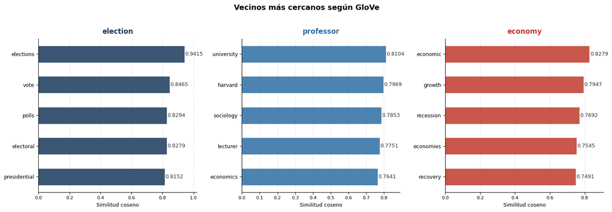

```python
# ── Datos ─────────────────────────────────────────────────────────
filas = []
for pc in palabras_consulta:
    vecinos = modelo.most_similar(pc, topn=5)
    for rango, (palabra, puntaje) in enumerate(vecinos, start=1):
        filas.append({
            "Palabra consulta": pc,
            "Rango": rango,
            "Vecino": palabra,
            "Similitud coseno": round(puntaje, 4)
        })

df_vecinos = pd.DataFrame(filas)

# ── Configuración ─────────────────────────────────────────────────
palabras_unicas = df_vecinos["Palabra consulta"].unique()
n_grupos        = len(palabras_unicas)
paleta          = ["#1a3a5c", "#2e6da4", "#c0392b"]   # un color por palabra consulta

fig, axes = plt.subplots(1, n_grupos, figsize=(5 * n_grupos, 5), sharey=False)

if n_grupos == 1:
    axes = [axes]

for ax, (pc, color) in zip(axes, zip(palabras_unicas, paleta)):
    sub = (df_vecinos[df_vecinos["Palabra consulta"] == pc]
           .sort_values("Similitud coseno"))          # orden ascendente → barra más larga arriba

    bars = ax.barh(
        sub["Vecino"],
        sub["Similitud coseno"],
        color=color, alpha=0.85,
        edgecolor="white", linewidth=0.6,
        height=0.55
    )

    # Etiqueta al final de cada barra
    for bar, val in zip(bars, sub["Similitud coseno"]):
        ax.text(
            val + 0.003,
            bar.get_y() + bar.get_height() / 2,
            f"{val:.4f}",
            va="center", ha="left",
            fontsize=9, color="#333333"
        )

    # Estilo por panel
    ax.set_title(pc, fontsize=12, fontweight="bold", color=color, pad=8)
    ax.set_xlabel("Similitud coseno", fontsize=9)
    ax.set_xlim(0, sub["Similitud coseno"].max() + 0.08)
    ax.spines[["top", "right"]].set_visible(False)
    ax.tick_params(axis="y", labelsize=9)
    ax.tick_params(axis="x", labelsize=8)
    ax.xaxis.grid(True, linestyle="--", alpha=0.4)
    ax.set_axisbelow(True)

fig.suptitle(
    "Vecinos más cercanos según GloVe",
    fontsize=13, fontweight="bold", y=1.02
)

plt.tight_layout()
plt.savefig("vecinos_barras.png", dpi=150, bbox_inches="tight")
plt.show()
```

**Interpretación:**

Las palabras seleccionadas y sus respectivos vecinos evidencian tanto la potencia como las limitaciones del modelo. Por un lado, GloVe logra capturar de manera consistente estructuras semánticas y sintácticas, organizando el lenguaje en clústeres coherentes. Sin embargo, en casos como Election y Professor, se hace evidente que estas asociaciones no son neutras, sino que responden al contexto específico del corpus en el que el modelo fue entrenado.

En este sentido, los resultados no deben interpretarse únicamente como relaciones lingüísticas, sino como reflejo de un discurso situado. Analizar los vecinos más cercanos implica, por tanto, una lectura crítica del corpus que los origina, permitiendo identificar no solo patrones de uso, sino también sesgos, énfasis y ausencias que el modelo reproduce

### 5. Razonamiento por Analogía

A diferencia de TF-IDF, que opera sobre superposición léxica, los embeddings estilo `Word2Vec` admiten **consultas de analogía** de la forma $A - B + C \approx D$, implementadas en gensim mediante `most_similar(positive=[A, C], negative=[B])`. Esta operación refleja una propiedad fundamental de los espacios vectoriales aprendidos: las relaciones semánticas y sintácticas entre palabras pueden representarse como transformaciones geométricas. En otras palabras, ciertas diferencias entre vectores capturan relaciones sistemáticas del lenguaje.

El razonamiento por analogía evidencia que los embeddings no solo codifican palabras de manera aislada, sino también las relaciones entre ellas, permitiendo que dimensiones latentes del espacio vectorial reflejen patrones como género, jerarquías o pertenencia institucional. Así, estas relaciones se estabilizan como direcciones consistentes en el espacio, lo que permite trasladarlas entre distintos pares de palabras.

Sin embargo, estos espacios no son neutrales. Los embeddings constituyen un reflejo del corpus en el que fueron entrenados, por lo que reproducen sus sesgos, énfasis y silencios. En el caso de Wikipedia en inglés, esto se traduce en una predominancia de marcos discursivos asociados al contexto académico y cultural del norte global. Por ello, el análisis de analogías y vecinos más cercanos trasciende lo técnico y se convierte en una herramienta interpretativa: permite identificar qué relaciones el corpus ha consolidado como sistemáticas y, en consecuencia, qué visiones del mundo han sido cristalizadas en la geometría del lenguaje.

A continuación se presentan dos analogías que permiten evidenciar las fortelezas y limitaciones señaladas.

### 5.1 Ejemplo 1: *President − Country + City ≈ ?*

**Consulta:** *President − Country + City ≈ ?*

Conceptualmente: ¿Si el presidente dirige el país, quien dirige la ciudad? Observemos a continuación, que responde el modelo:

```python
# Funciones auxiliares
def en_vocab_check(w, m):
    return w in m.key_to_index

def verificar_tokens(m, tokens):
    return [t for t in tokens if not en_vocab_check(t, m)]

def analogia(m, positivos, negativos, topn=5):
    return m.most_similar(positive=positivos, negative=negativos, topn=topn)

# ── Analogía 1 ────────────────────────────────────────────────────
pos1 = ["president", "city"]
neg1 = ["country"]

faltantes1 = verificar_tokens(modelo, pos1 + neg1)
if not faltantes1:
    resultados1 = analogia(modelo, positivos=pos1, negativos=neg1, topn=5)
    df_a1 = pd.DataFrame(resultados1, columns=["Palabra", "Similitud coseno"])
    df_a1["Similitud coseno"] = df_a1["Similitud coseno"].round(4)
    df_a1.index += 1
    print("president − country + city ≈")
    print(df_a1.to_string())
else:
    print("Tokens faltantes:", faltantes1)
```

```
president − country + city ≈
    Palabra  Similitud coseno
1     mayor            0.7624
2      vice            0.6538
3    office            0.5881
4  governor            0.5594
5    former            0.5466
```

**Interpretación:**

El resultado **"mayor"** confirma que GloVe capturó la estructura jerarquica del poder político como una transformación geométrica consistente en el espacio de embeddings. La analogía president − country + city reproduce correctamente lo esperado: así como el president es la autoridad ejecutiva máxima de un country, el mayor lo es de una city.

Esto es teóricamente relevante por dos razones. Lo primero, el modelo no fue entrenado con reglas gramaticales ni ontologías políticas. Es decir que, aprendió esta relación exclusivamente de patrones de co-ocurrencia en texto. Que pueda recuperarla sugiere que la jerarquía territorial del poder está profundamente codificada en el discurso del corpus, apareciendo de forma consistente en suficientes contextos como para que el modelo logre identifcar una dirección vectorial estable.

Lo segundo, el hecho de que la analogía funcione implica que president:country y mayor:city se usan en el corpus de maneras estructuralmente paralelas, es decir, en los mismos tipos de oraciones, con los mismos verbos, en los mismos géneros textuales. El embedding no captura el concepto de autoridad en abstracto, sino cómo se habla de la autoridad en Wikipedia en inglés, que es predominantemente un discurso institucional y descriptivo, no crítico.

### 5.2 Ejemplo 2: *bride − woman + man ≈ ?*

**Consulta:** *bride − woman + man ≈ ?*

Conceptualmente, Bride es a novia como Man es a Groom. Observemos a continuación que nos arroja el modelo:

```python
# ── Analogía 2 ────────────────────────────────────────────────────
pos2 = ["bride", "man"]
neg2 = ["woman"]

faltantes2 = verificar_tokens(modelo, pos2 + neg2)
if not faltantes2:
    resultados2 = analogia(modelo, positivos=pos2, negativos=neg2, topn=5)
    df_a2 = pd.DataFrame(resultados2, columns=["Palabra", "Similitud coseno"])
    df_a2["Similitud coseno"] = df_a2["Similitud coseno"].round(4)
    df_a2.index += 1
    print("bride − woman + man ≈")
    print(df_a2.to_string())
else:
    print("Tokens faltantes:", faltantes2)
```

```
bride − woman + man ≈
      Palabra  Similitud coseno
1       groom            0.6931
2  bridegroom            0.6633
3     wedding            0.6462
4         son            0.5576
5       lover            0.5533
```

**Interpretación:**

**"Groom"** y **"bridegroom"** son exactamente la respuesta esperada, y además son sinónimos entre sí, lo que confirma que el modelo capturó el rol con mucha precisión. Esto evidencia que GloVe capturó correctamente la **simetría de roles de género en el matrimonio** como una transformación geométrica consistente. La analogía `bride − woman + man` recupera sin ambigüedad el rol masculino equivalente.

Sin embargo, los vecinos secundarios son sociológicamente sugestivos: la aparición de *son* en cuarta posición indica que en el corpus el hombre en contexto matrimonial se asocia frecuentemente con su rol filial, mientras que *lover* introduce una dimensión afectiva que no tiene equivalente simétrico en el lado femenino de la analogía. Nuevamente observamos como estas asimetrías no son errores del modelo son huellas del discurso que lo entrenó.

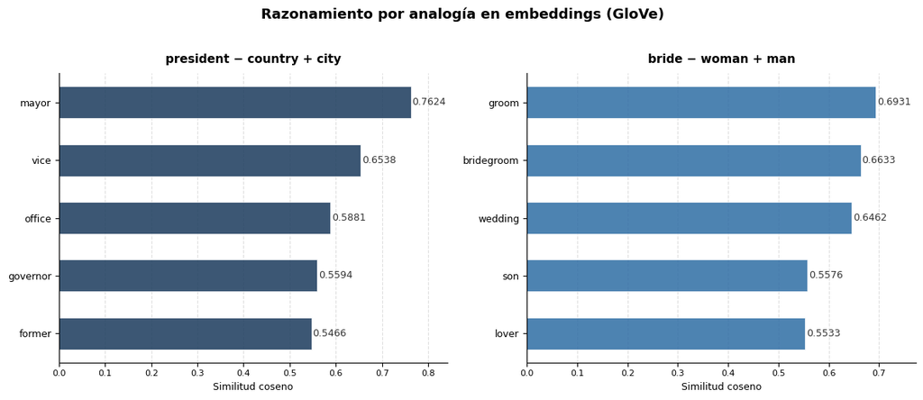

```python
import matplotlib.pyplot as plt

fig, axes = plt.subplots(1, 2, figsize=(12, 5))

# ── Configuración por panel ──────────────────────────────────────
paneles = [
    (axes[0], df_a1, "president − country + city", "#1a3a5c"),
    (axes[1], df_a2, "bride − woman + man",         "#2e6da4"),
]

for ax, df, titulo, color in paneles:
    # Ordenar ascendente para que el mayor quede arriba
    df_plot = df.sort_values("Similitud coseno", ascending=True)

    bars = ax.barh(
        df_plot["Palabra"],
        df_plot["Similitud coseno"],
        color=color, alpha=0.85,
        edgecolor="white", linewidth=0.6,
        height=0.55
    )

    # Etiqueta al final de cada barra
    for bar, val in zip(bars, df_plot["Similitud coseno"]):
        ax.text(
            val + 0.003,
            bar.get_y() + bar.get_height() / 2,
            f"{val:.4f}",
            va="center", ha="left",
            fontsize=9, color="#333333"
        )

    ax.set_title(titulo, fontsize=11, fontweight="bold", pad=10)
    ax.set_xlabel("Similitud coseno", fontsize=9)
    ax.set_xlim(0, df_plot["Similitud coseno"].max() + 0.08)
    ax.spines[["top", "right"]].set_visible(False)
    ax.tick_params(axis="y", labelsize=9)
    ax.tick_params(axis="x", labelsize=8)
    ax.xaxis.grid(True, linestyle="--", alpha=0.4)
    ax.set_axisbelow(True)

fig.suptitle(
    "Razonamiento por analogía en embeddings (GloVe)",
    fontsize=13, fontweight="bold", y=1.02
)

plt.tight_layout()
plt.savefig("analogias.png", dpi=150, bbox_inches="tight")
plt.show()
```

### 6. Matriz de Similitud entre Palabras

Calculamos la similitud coseno por pares para un conjunto de seis palabras temáticamente relacionadas.

Valores cercanos a 1.0 indican que las dos palabras aparecen en contextos muy similares en el corpus (son casi intercambiables desde el punto de vista distribuciona)l. Valores cercanos a 0 indican que las palabras viven en regiones muy distintas del espacio vectorial y raramente co-ocurren en los mismos contextos

```python
palabras_matriz = ["democracy", "president", "election", "parliament", "vote", "party"]

# Verificar que todas estén en el vocabulario
faltantes_m = verificar_tokens(modelo, palabras_matriz)
if faltantes_m:
    print("Faltantes:", faltantes_m)

# Construir matriz de similitud
n = len(palabras_matriz)
sim_matriz = np.zeros((n, n))

for i in range(n):
    for j in range(n):
        sim_matriz[i, j] = modelo.similarity(palabras_matriz[i], palabras_matriz[j])

df_sim = pd.DataFrame(
    sim_matriz.round(4),
    index   = palabras_matriz,
    columns = palabras_matriz
)

print("Matriz de similitud coseno por pares:\n")
print(df_sim.to_string())
```

```
Matriz de similitud coseno por pares:

            democracy  president  election  parliament    vote   party
democracy      1.0000     0.4943    0.5162      0.4468  0.4732  0.5898
president      0.4943     1.0000    0.6091      0.5238  0.5176  0.6024
election       0.5162     0.6091    1.0000      0.6688  0.8465  0.7481
parliament     0.4468     0.5238    0.6688      1.0000  0.7074  0.6587
vote           0.4732     0.5176    0.8465      0.7074  1.0000  0.7007
party          0.5898     0.6024    0.7481      0.6587  0.7007  1.0000
```

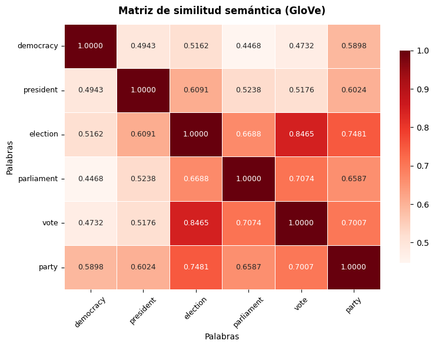

```python
import matplotlib.pyplot as plt
import seaborn as sns

fig, ax = plt.subplots(figsize=(8, 6))

sns.heatmap(
    df_sim,
    annot=True,
    fmt=".4f",
    cmap="Reds",
    linewidths=0.4,
    linecolor="white",
    annot_kws={"size": 9},
    ax=ax,
    cbar_kws={"shrink": 0.8}
)

ax.set_title(
    "Matriz de similitud semántica (GloVe)",
    fontsize=12, fontweight="bold", pad=12
)
ax.set_xlabel("Palabras", fontsize=10)
ax.set_ylabel("Palabras", fontsize=10)
ax.tick_params(axis="x", rotation=45, labelsize=9)
ax.tick_params(axis="y", rotation=0,  labelsize=9)

plt.tight_layout()
plt.savefig("matriz_similitud.png", dpi=150, bbox_inches="tight")
plt.show()
```

**Interpretación:**

La matriz revela dos clústeres semánticos claramente diferenciados dentro del dominio político. El primero agrupa *election*, *vote* y *parliament* con similitudes que oscilan entre 0.67 y 0.85, siendo el par *election/vote* el más cercano de toda la matriz (0.8465), lo que indica que en el corpus ambas palabras aparecen de manera casi intercambiable en los mismos contextos, típicamente en cobertura mediática de procesos electorales. *Party* actúa como puente entre los dos clústeres, con similitudes moderadamente altas hacia *election* (0.75), *vote* (0.70) y *parliament* (0.66), reflejando que el partido político es el actor que conecta la competencia electoral con la representación institucional.

El segundo hallazgo interesante son los resultados de *democracy* en la matriz. A pesar de ser el concepto más general del conjunto de palabras, sus similitudes con todas las demás son las más bajas (nunca supera 0.59) y su valor más bajo es precisamente con *parliament* (0.4468). Esto sugiere que en el corpus el concepto de democracia no se usa en los mismos contextos inmediatos que los mecanismos concretos del proceso democrático. Desde una perspectiva crítica, esta separación vectorial entre el ideal (democracy) y sus mecanismos (vote, election, parliament) es en sí misma una lectura del discurso dominante en Wikipedia.

### 7. De Palabras a Similitud Textual

### 7.1 Definición de Oraciones

Reutilizamos tres oraciones temáticamente variadas, análogas a las empleadas en actividades previas de TF-IDF:

```python
oracion_1 = "Political institutions shape public policy and influence democratic governance."
oracion_2 = "Public policy decisions affect economic development and social outcomes."
oracion_3 = "Democratic governance relies on institutions, political participation, and public trust."

oraciones = {
    "O1": oracion_1,
    "O2": oracion_2,
    "O3": oracion_3
}

for etiqueta, oracion in oraciones.items():
    print(f"{etiqueta}: {oracion}")
```

```
O1: Political institutions shape public policy and influence democratic governance.
O2: Public policy decisions affect economic development and social outcomes.
O3: Democratic governance relies on institutions, political participation, and public trust.
```

### 7.2 Verificación de Tokens OOV

A continuación, realizamos el proceso de normalización del texto.

```python
import re, unicodedata

def normalizar_texto(s):
    """Minúsculas, eliminar diacríticos, quitar caracteres no alfabéticos."""
    s = s.lower()
    s = unicodedata.normalize("NFKD", s).encode("ascii", "ignore").decode("utf-8")
    s = re.sub(r"[^a-z\s]+", " ", s)
    s = re.sub(r"\s+", " ", s).strip()
    return s

def tokens_oov(m, s):
    toks = normalizar_texto(s).split()
    return [t for t in toks if t not in m.key_to_index]

print("── Texto normalizado ────────────────────────────────────────")
for etiqueta, oracion in oraciones.items():
    print(f"{etiqueta} original  : {oracion}")
    print(f"{etiqueta} procesado : {normalizar_texto(oracion)}")
    print()

print("── Verificación OOV ─────────────────────────────────────────")
for etiqueta, oracion in oraciones.items():
    oov = tokens_oov(modelo, oracion)
    estado = f"Tokens OOV: {oov}" if oov else "Todos los tokens en vocabulario ✔"
    print(f"{etiqueta} — {estado}")
```

```
── Texto normalizado ────────────────────────────────────────
O1 original  : Political institutions shape public policy and influence democratic governance.
O1 procesado : political institutions shape public policy and influence democratic governance

O2 original  : Public policy decisions affect economic development and social outcomes.
O2 procesado : public policy decisions affect economic development and social outcomes

O3 original  : Democratic governance relies on institutions, political participation, and public trust.
O3 procesado : democratic governance relies on institutions political participation and public trust

── Verificación OOV ─────────────────────────────────────────
O1 — Todos los tokens en vocabulario ✔
O2 — Todos los tokens en vocabulario ✔
O3 — Todos los tokens en vocabulario ✔
```

### 7.3 Embedding Promedio + Similitud Coseno

En este ejercicio se utilizará el embedding promedio como representación de la oración. Es decir que, cada oración se convierte en un único vector tomando la media aritmética de los vectores de sus palabras. Lo anterior, apoyado en la similitud coseno como métrica de comparación.

Vale la pena mencionar, que a diferencia de la distancia euclidiana, el coseno ignora la magnitud de los vectores y mide únicamente el ángulo entre ellos, lo que lo hace robusto ante oraciones de distinta longitud.

Un valor de 1.0 significaría que las dos oraciones apuntan exactamente en la misma dirección semántica; un valor de 0 indicaría ortogonalidad completa, es decir, ninguna relación semántica detectable.

Al ser un cálculo basado en el promedio, podemos anticipar su limitación. Al tratar todas las palabras con la misma importancia, sin distinguir entre palabras de contenido y palabras funcionales (the, at, in) resulta útil para capturar el tema general, pero insensible al orden, la sintaxis o el peso relativo de cada término.

```python
def vector_oracion_promedio(m, s):
    """Calcula el embedding promedio de una oración (se excluyen tokens OOV)."""
    toks = normalizar_texto(s).split()
    toks = [t for t in toks if t in m.key_to_index]
    if not toks:
        return None
    return np.mean([m[t] for t in toks], axis=0)

def coseno(u, v):
    """Similitud coseno entre dos vectores."""
    if u is None or v is None:
        return None
    nu, nv = np.linalg.norm(u), np.linalg.norm(v)
    if nu == 0 or nv == 0:
        return None
    return float(np.dot(u, v) / (nu * nv))

v1 = vector_oracion_promedio(modelo, oracion_1)
v2 = vector_oracion_promedio(modelo, oracion_2)
v3 = vector_oracion_promedio(modelo, oracion_3)

cos12 = coseno(v1, v2)
cos13 = coseno(v1, v3)
cos23 = coseno(v2, v3)

df_cos = pd.DataFrame({
    "Par"              : ["(O1, O2)", "(O1, O3)", "(O2, O3)"],
    "Similitud coseno" : [round(cos12,4), round(cos13,4), round(cos23,4)]
})

print(df_cos.to_string(index=False))
```

```
     Par  Similitud coseno
(O1, O2)            0.9241
(O1, O3)            0.9649
(O2, O3)            0.9137
```

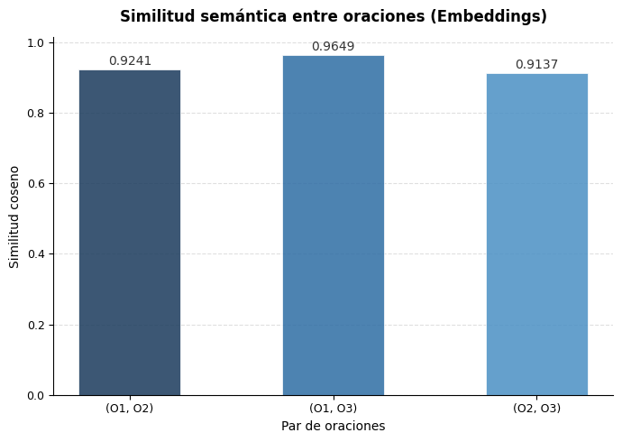

```python
import matplotlib.pyplot as plt

fig, ax = plt.subplots(figsize=(7, 5))

colores = ["#1a3a5c", "#2e6da4", "#4a90c4"]

bars = ax.bar(
    df_cos["Par"],
    df_cos["Similitud coseno"],
    color=colores, alpha=0.85,
    edgecolor="white", linewidth=0.6,
    width=0.5
)

# Etiqueta encima de cada barra
for bar, val in zip(bars, df_cos["Similitud coseno"]):
    ax.text(
        bar.get_x() + bar.get_width() / 2,
        val + 0.005,
        f"{val:.4f}",
        ha="center", va="bottom",
        fontsize=10, color="#333333"
    )

ax.set_title(
    "Similitud semántica entre oraciones (Embeddings)",
    fontsize=12, fontweight="bold", pad=12
)
ax.set_xlabel("Par de oraciones", fontsize=10)
ax.set_ylabel("Similitud coseno",  fontsize=10)
ax.set_ylim(0, df_cos["Similitud coseno"].max() + 0.05)
ax.spines[["top", "right"]].set_visible(False)
ax.yaxis.grid(True, linestyle="--", alpha=0.4)
ax.set_axisbelow(True)
ax.tick_params(axis="both", labelsize=9)

plt.tight_layout()
plt.savefig("similitud_oraciones.png", dpi=150, bbox_inches="tight")
plt.show()
```

**Interpretación**

Lo primero que llama la atención es que todos los valores son muy altos (por encima de 0.91), lo que sugiere que las tres oraciones, independientemente de su temática, comparten una región semántica general en el espacio vectorial.

El par más similar (O1, O3) con 0.9649 confirma que el embedding promedio capturó correctamente la proximidad temática entre las dos oraciones de dominio político puro. Esto nos permite concluir que sus términos viven en la misma región del espacio vectorial, y al promediar sus tokens el vector resultante apunta en direcciones muy cercanas.

La oración (O2) se aleja de ambas no porque sea una oración no política, sino porque introduce vocabulario del dominio económico, términos como *economic* y *development*, que es posible que arrastre su vector promedio hacia una región distinta del espacio. Esto ilustra perfectamente la sensibilidad del embedding; basta con que dos o tres palabras de contenido pertenezcan a un dominio adyacente para desplazar el centro de gravedad semántico de toda la oración.

### 7.4 Comparación con TF-IDF

```python
from sklearn.feature_extraction.text import TfidfVectorizer
from sklearn.metrics.pairwise import cosine_similarity

corpus = [oracion_1, oracion_2, oracion_3]
vectorizador = TfidfVectorizer()
matriz_tfidf = vectorizador.fit_transform(corpus)

tfidf_cos12 = cosine_similarity(matriz_tfidf[0], matriz_tfidf[1])[0][0]
tfidf_cos13 = cosine_similarity(matriz_tfidf[0], matriz_tfidf[2])[0][0]
tfidf_cos23 = cosine_similarity(matriz_tfidf[1], matriz_tfidf[2])[0][0]

df_comparacion = pd.DataFrame({
    "Par"                 : ["(O1, O2)", "(O1, O3)", "(O2, O3)"],
    "Coseno (Embedding)"  : [round(cos12,4), round(cos13,4), round(cos23,4)],
    "Coseno (TF-IDF)"     : [round(tfidf_cos12,4), round(tfidf_cos13,4), round(tfidf_cos23,4)]
})

print(df_comparacion.to_string(index=False))
```

```
     Par  Coseno (Embedding)  Coseno (TF-IDF)
(O1, O2)              0.9241           0.2001
(O1, O3)              0.9649           0.4810
(O2, O3)              0.9137           0.0977
```

**Análisis comparado:**

Los resultados evidencian las principales diferencias entre ambos métodos. El embedding promedio asigna valores por encima de 0.91 a todos los pares, mientras que TF-IDF no supera 0.48 y, en el caso de (O2, O3), desciende hasta 0.09. Esta diferencia responde a la naturaleza de lo que cada enfoque mide.

Como lo expusimos en el trabajo anterior, TF-IDF se basa en la superposición léxica exacta, por lo que, si dos oraciones no comparten palabras, su similitud tiende a ser cercana a cero, independientemente de su contenido. Dado que las oraciones fueron construidas con vocabulario distinto, TF-IDF las interpreta como prácticamente ajenas entre sí muy a pesar de que en el fondo, hablan de lo mismo.

Vale la pena señalar, que si logramos observamos como ambos métodos capturan la jerarquía de similitud: (O1, O3) es el par más cercano y (O2, O3) el más distante. Esto indica que ambos enfoques reconocen una misma estructura relativa, pero el embedding lo hace a partir del significado, mientras que TF-IDF se limita a la coincidencia de términos. La incorporación de palabras como *economic* y *development* en O2 introduce una variación moderada en el embedding, pero en TF-IDF genera una ruptura casi total de comparabilidad.

### 8. Reflexión final

Los word embeddings como GloVe y Word2Vec representan un salto sustancia hacia la comprensión del lenguaje natural respecto a los enfoques basados en frecuencia. Mientras TF-IDF codifica *qué palabras* aparecen en un documento y *con qué frecuencia*, los embeddings codifican *qué significan esas palabras* aprovechando patrones de co-ocurrencia en un gran corpus. Como resultado, expresiones semánticamente equivalentes *"discussed findings"* vs. *"explained results"* pueden reconocerse como relacionadas aunque no compartan ninguna forma superficial.

Una limitación importante de los embeddings estáticos tipo Word2Vec es la **insensibilidad al contexto**: cada palabra recibe un único vector fijo independientemente de la oración en que aparezca. La palabra *party*, por ejemplo, recibe la misma representación tanto en el sentido político como en el de celebraciones.

**Los embeddings son generalmente preferibles a TF-IDF cuando:**

1. El lenguaje es variado y necesitas reconocer ideas similares aunque se expresen con palabras distintas, como en búsquedas o preguntas.
2. Los textos son cortos o tienen pocas palabras en común.
3. El modelo que vas a usar trabaja mejor con datos numéricos continuos, como ocurre con las redes neuronales.

**TF-IDF puede seguir siendo adecuado cuando** la coincidencia exacta de palabras clave es suficiente, los recursos computacionales son limitados, o se requiere interpretabilidad de los pesos de las características.

### 9. Información de Versiones

```python
import sys, sklearn

print(f"Python   : {sys.version}")
print(f"numpy    : {np.__version__}")
print(f"gensim   : {gensim.__version__}")
print(f"sklearn  : {sklearn.__version__}")
print(f"pandas   : {pd.__version__}")
```

```
Python   : 3.13.5 | packaged by Anaconda, Inc. | (main, Jun 12 2025, 11:09:21) [Clang 14.0.6 ]
numpy    : 2.4.2
gensim   : 4.4.0
sklearn  : 1.8.0
pandas   : 3.0.1
```